[figure not shown]

Лабораторная работа №3: Daisyworld

Агентная модель саморегуляции планетарного климата

Федорова Анжелика Игоревна

2026-03-21

[figure not shown]

Содержание i

1

Вводная часть

2

Реализация модели

3

Базовая визуализация

4

Динамика системы

5

Параметрические эксперименты

6

Результаты

7

Выводы

Раздел 1

Вводная часть

[figure not shown]

Цель работы

Реализовать агентную модель Daisyworld, провести вычислительные эксперименты и исследовать

поведение системы при различных параметрах.

[figure not shown]

Задачи

Создать структуру проекта с использованием DrWatson

Установить необходимые пакеты (Agents.jl, CairoMakie, DataFrames, …)

Реализовать модель Daisyworld на Julia

Выполнить визуализацию состояния модели по шагам

Построить графики динамики числа маргариток и температуры

Провести параметрические эксперименты

[figure not shown]

Задачи

Создать структуру проекта с использованием DrWatson

Установить необходимые пакеты (Agents.jl, CairoMakie, DataFrames, …)

Реализовать модель Daisyworld на Julia

Выполнить визуализацию состояния модели по шагам

Построить графики динамики числа маргариток и температуры

Провести параметрические эксперименты

[figure not shown]

Задачи

Создать структуру проекта с использованием DrWatson

Установить необходимые пакеты (Agents.jl, CairoMakie, DataFrames, …)

Реализовать модель Daisyworld на Julia

Выполнить визуализацию состояния модели по шагам

Построить графики динамики числа маргариток и температуры

Провести параметрические эксперименты

[figure not shown]

Задачи

Создать структуру проекта с использованием DrWatson

Установить необходимые пакеты (Agents.jl, CairoMakie, DataFrames, …)

Реализовать модель Daisyworld на Julia

Выполнить визуализацию состояния модели по шагам

Построить графики динамики числа маргариток и температуры

Провести параметрические эксперименты

[figure not shown]

Задачи

Создать структуру проекта с использованием DrWatson

Установить необходимые пакеты (Agents.jl, CairoMakie, DataFrames, …)

Реализовать модель Daisyworld на Julia

Выполнить визуализацию состояния модели по шагам

Построить графики динамики числа маргариток и температуры

Провести параметрические эксперименты

[figure not shown]

Задачи

Создать структуру проекта с использованием DrWatson

Установить необходимые пакеты (Agents.jl, CairoMakie, DataFrames, …)

Реализовать модель Daisyworld на Julia

Выполнить визуализацию состояния модели по шагам

Построить графики динамики числа маргариток и температуры

Провести параметрические эксперименты

Раздел 2

Реализация модели

[figure not shown]

Агенты и среда

Агенты: маргаритки двух пород — чёрные (albedo = 0.25) и белые (albedo = 0.75)

Среда: сетка GridSpaceSingle размером 30 × 30

Атрибуты агента: порода (breed), возраст (age), альбедо (albedo)

[figure not shown]

Агенты и среда

Агенты: маргаритки двух пород — чёрные (albedo = 0.25) и белые (albedo = 0.75)

Среда: сетка GridSpaceSingle размером 30 × 30

Атрибуты агента: порода (breed), возраст (age), альбедо (albedo)

[figure not shown]

Агенты и среда

Агенты: маргаритки двух пород — чёрные (albedo = 0.25) и белые (albedo = 0.75)

Среда: сетка GridSpaceSingle размером 30 × 30

Атрибуты агента: порода (breed), возраст (age), альбедо (albedo)

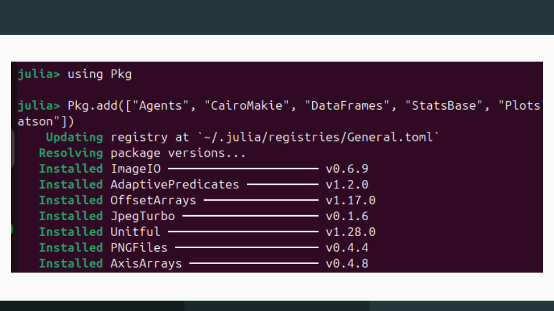

Установка зависимостей

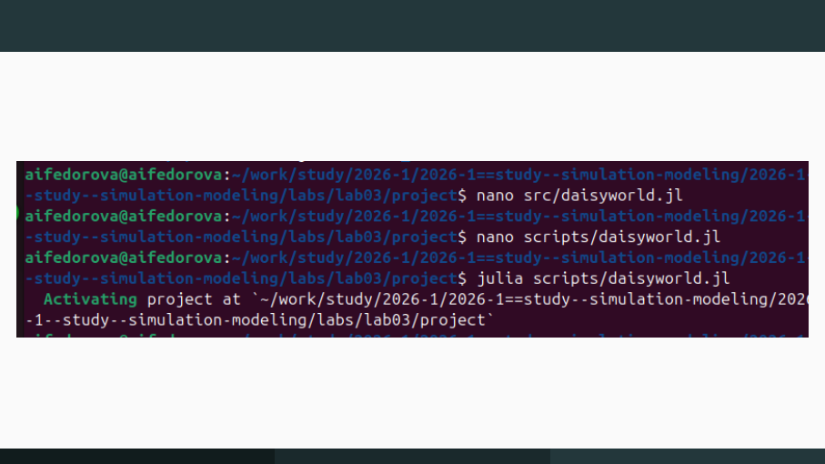

Запуск модели

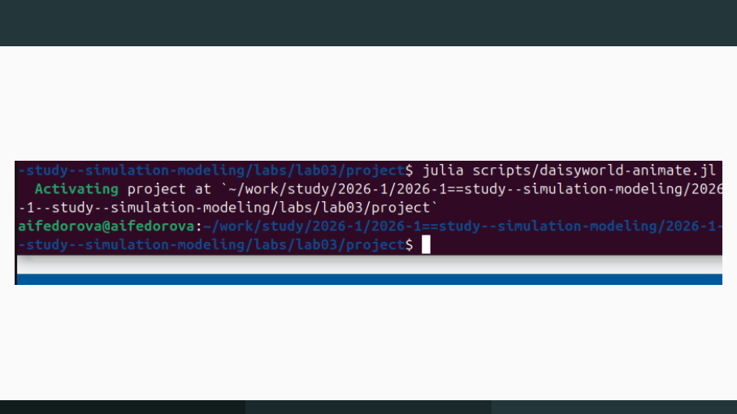

Генерация анимации

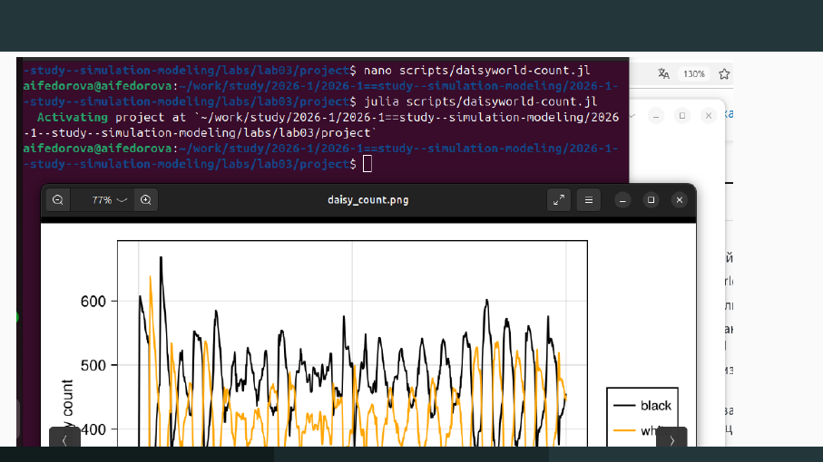

Построение графика численности

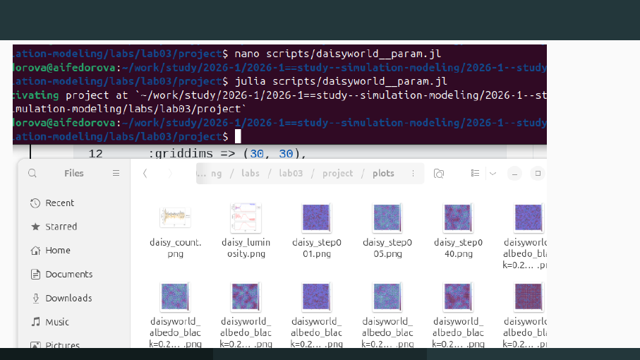

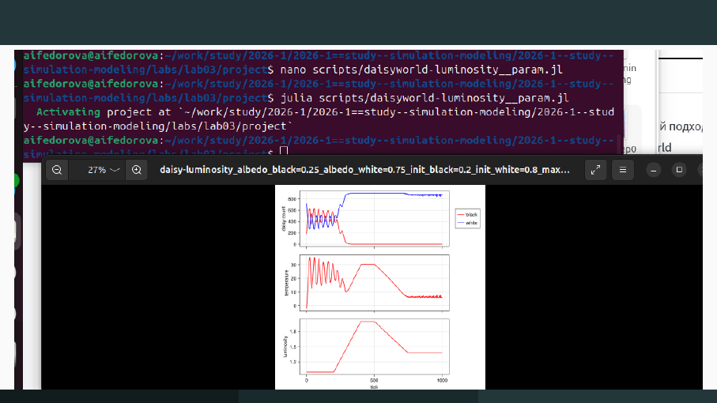

Параметрические эксперименты (скриншот)

[figure not shown]

Процессы модели

Нагрев поверхности — поглощённая светимость → локальный нагрев по логарифмическому

закону

Диффузия температуры — усреднение с 8 соседями (ratio = 0.5)

Размножение — квадратичная вероятность посева от температуры

Старение — агент удаляется по достижении max_age = 25 шагов

[figure not shown]

Процессы модели

Нагрев поверхности — поглощённая светимость → локальный нагрев по логарифмическому

закону

Диффузия температуры — усреднение с 8 соседями (ratio = 0.5)

Размножение — квадратичная вероятность посева от температуры

Старение — агент удаляется по достижении max_age = 25 шагов

[figure not shown]

Процессы модели

Нагрев поверхности — поглощённая светимость → локальный нагрев по логарифмическому

закону

Диффузия температуры — усреднение с 8 соседями (ratio = 0.5)

Размножение — квадратичная вероятность посева от температуры

Старение — агент удаляется по достижении max_age = 25 шагов

[figure not shown]

Процессы модели

Нагрев поверхности — поглощённая светимость → локальный нагрев по логарифмическому

закону

Диффузия температуры — усреднение с 8 соседями (ratio = 0.5)

Размножение — квадратичная вероятность посева от температуры

Старение — агент удаляется по достижении max_age = 25 шагов

Раздел 3

Базовая визуализация

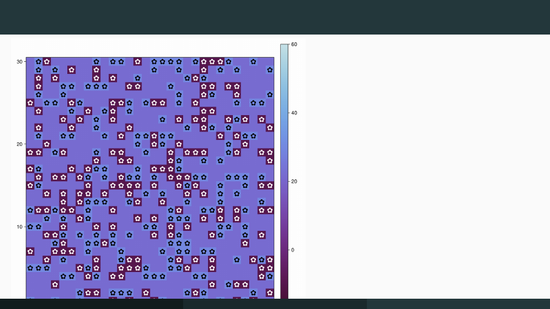

Шаг 1 — начальное состояние

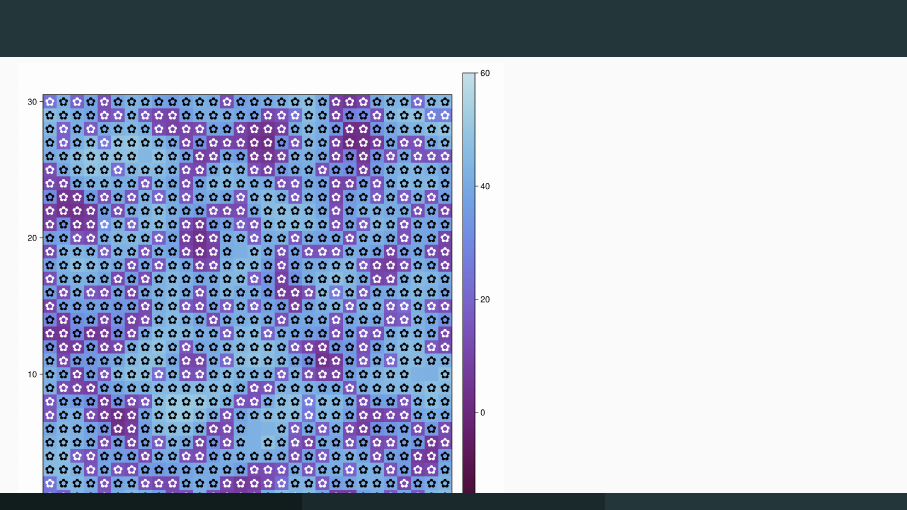

Шаг 5 — заселение

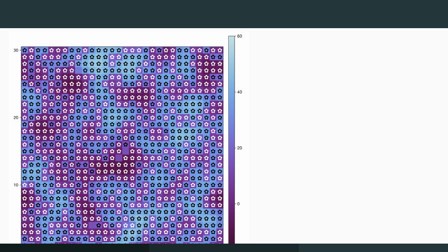

Шаг 40 — устойчивая структура

Анализ: начальное распределение случайное → кластеризация маргариток → формируется

устойчивая пространственная структура.

Раздел 4

Динамика системы

Динамика числа маргариток

Быстрый рост популяции в первые 50 шагов

Устойчивые колебания в диапазоне 300–650 особей

Популяции чёрных и белых колеблются в антифазе

Динамика числа маргариток

Быстрый рост популяции в первые 50 шагов

Устойчивые колебания в диапазоне 300–650 особей

Популяции чёрных и белых колеблются в антифазе

Динамика числа маргариток

Быстрый рост популяции в первые 50 шагов

Устойчивые колебания в диапазоне 300–650 особей

Популяции чёрных и белых колеблются в антифазе

Динамика при изменении светимости (сценарий :ramp)

При росте светимости (шаги 200–400) белые маргаритки доминируют

Температура следует за светимостью, но сглаживается биотой

Динамика при изменении светимости (сценарий :ramp)

При росте светимости (шаги 200–400) белые маргаритки доминируют

Температура следует за светимостью, но сглаживается биотой

Динамика при изменении светимости (сценарий :ramp)

При росте светимости (шаги 200–400) белые маргаритки доминируют

Температура следует за светимостью, но сглаживается биотой

Раздел 5

Параметрические эксперименты

[figure not shown]

Параметры экспериментов

Параметр Значения Эффект

max_age 25 / 40 Рост max_age стабилизирует колебания

init_white 0.2 / 0.8 Высокая доля белых охлаждает планету

scenario :default / :ramp Ramp демонстрирует гипотезу Гайи

solar_change 0.005 Определяет «остроту» реакции экосистемы

[figure not shown]

Метод перебора параметров

DrWatson автоматически генерирует все комбинации и сохраняет результаты с параметрами в именах

файлов:

param_dict = Dict(

:max_age => [25, 40],

:init_white => [0.2, 0.8],

:scenario => :default,

:seed => 165,

)

for params in dict_list(param_dict)

model = daisyworld(; params...)

...

end

Раздел 6

Результаты

[figure not shown]

Общий анализ

Устойчивость — модель выходит на устойчивый режим при широком диапазоне начальных

условий

Адаптация — при изменении солнечной светимости экосистема перестраивает состав популяций,

сглаживая температуру

Баланс агентов — чёрные и белые маргаритки образуют конкурентно-кооперативную

регуляторную пару

Гипотеза Гайи — результаты подтверждают концепцию Watson & Lovelock: живые организмы

активно регулируют климат планеты

[figure not shown]

Общий анализ

Устойчивость — модель выходит на устойчивый режим при широком диапазоне начальных

условий

Адаптация — при изменении солнечной светимости экосистема перестраивает состав популяций,

сглаживая температуру

Баланс агентов — чёрные и белые маргаритки образуют конкурентно-кооперативную

регуляторную пару

Гипотеза Гайи — результаты подтверждают концепцию Watson & Lovelock: живые организмы

активно регулируют климат планеты